# Christian Attitudes - Chi-Squared Test

- Show All Code
- Hide All Code

Course MATH 325

Author

Lexi Soelberg

```r
library(ggplot2)
library(plotly)
library(mosaic)
library(car)
library(tidyverse)
library(pander)
library(DT)
library(dplyr)
library(readr)
library(haven)

gss2021 <- read_sas("../../data/gss2021.sas7bdat", NULL)
```

# Background

**Counts & Hypothesis**

```r
table(gss2021$REBORN) %>%
  setNames(c("Yes", "No")) %>%
  pander("Responses for Reborn")
```

Responses for Reborn

| Yes | No |
| --- | --- |
| 1423 | 2507 |

```r
table(gss2021$SAVESOUL) %>%
  setNames(c("Yes", "No")) %>%
  pander("Responses for SaveSoul")
```

Responses for SaveSoul

| Yes | No |
| --- | --- |
| 1461 | 2488 |

```r
table(gss2021$REBORN, gss2021$SAVESOUL) %>%
  `rownames<-`(c("Yes", "No")) %>%
  `colnames<-`(c("Yes", "No")) %>%
  pander("Cross-tabulation of Reborn and SaveSoul")
```

Cross-tabulation of Reborn and SaveSoul

|  | Yes | No |
| --- | --- | --- |
| **Yes** | 1030 | 384 |
| **No** | 413 | 2084 |

As we can see here the counts are almost equal for the Yes and No groups in the `Reborn` and `SaveSoul` respondents. Just over 1400 people who said Yes to being reborn in Christ and near-equal counts for those who are willing to convince others of Christ.

In the 3rd table we can see who answered yes to both, yes and no to one, no and yes to another and no to both.

### Hypothesis

$$H_0: \text{Having a Born Again experience is not associated (or independent) with trying to convince others of Jesus Christ}$$

$$H_a: \text{Having a Born Again experience is associated with trying to convince others of Jesus Christ}$$

$\alpha$ = 0.5

**Table & Chart**

```r
Jesustable <- table(gss2021$REBORN, gss2021$SAVESOUL)

rownames(Jesustable) <- c("BORN AGAIN", "NOT BORN AGAIN") #these replace the 1, 2, and 3

colnames(Jesustable) <- c("CONVINCE OF CHRIST", "DON'T CONVINCE CHRIST") #these replace the 1 and 2\

Jesustable %>%
  pander(caption="2021 General Social Survey Results", split.table=Inf)
```

2021 General Social Survey Results

|  | CONVINCE OF CHRIST | DON’T CONVINCE CHRIST |
| --- | --- | --- |
| **BORN AGAIN** | 1030 | 384 |
| **NOT BORN AGAIN** | 413 | 2084 |

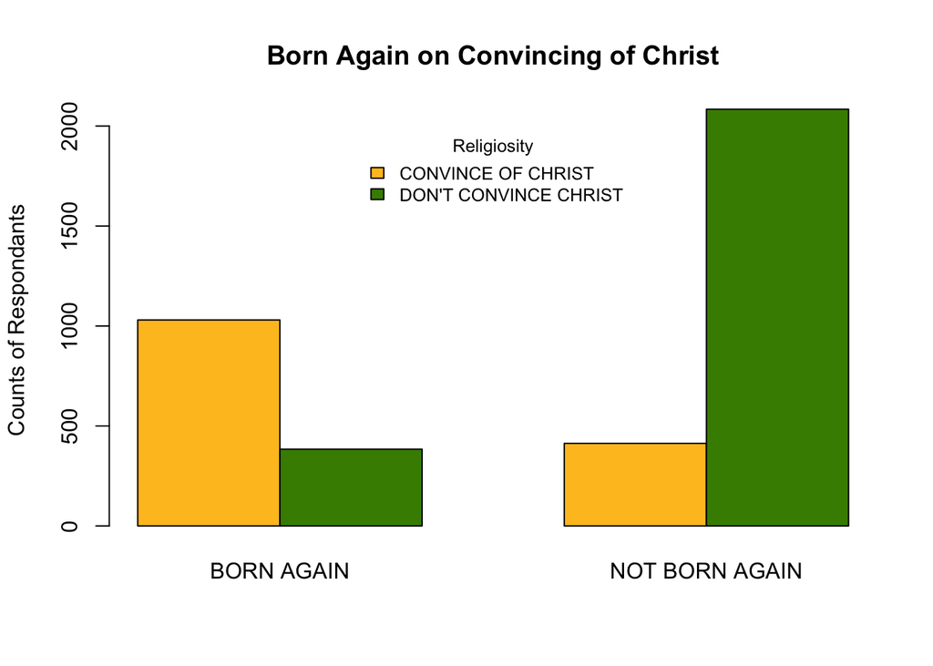

```r
barplot(
  t(Jesustable),
  beside = TRUE,
  legend.text = TRUE,
  args.legend = list(
    title = "Religiosity",
    x = "top",
    inset = 0.05,
    cex = 0.8,
    bty = 'n',
    horiz = FALSE
  ),
  col = c("goldenrod1", "chartreuse4"),
  main = "Born Again on Convincing of Christ",
  ylab = "Counts of Respondants"
)
```

In the graph above we might be tempted to observe a correlation of those who are `Born Again` on their willingness to `Convince of Christ`. Let’s run a $X^2$ test statistic to see if the findings are significant enough to reject our $H_0$ hypothesis.

**X^2 Test**

We will start by looking at our expected and observed counts.

```r
Jesustest <- chisq.test(Jesustable)

Jesustest$expected %>% pander()
```

|  | CONVINCE OF CHRIST | DON’T CONVINCE CHRIST |
| --- | --- | --- |
| **BORN AGAIN** | 521.7 | 892.3 |
| **NOT BORN AGAIN** | 921.3 | 1576 |

To make sure these counts are valid and that we can move on to tunning the test statistic we make sure all counts are above 5, which they are.

We are expecting to see more people spread out, what we are actually seeing is the extremes being represented more. The `Born Again` and `Convince of Christ` and the `Not Born Again` and `Don't Convince of Christ` group are the largest with the other two being the outliers.

```r
Jesustest$observed %>% pander()
```

|  | CONVINCE OF CHRIST | DON’T CONVINCE CHRIST |
| --- | --- | --- |
| **BORN AGAIN** | 1030 | 384 |
| **NOT BORN AGAIN** | 413 | 2084 |

Now we will run our test to see how significant these observed counts are from the expected.

```r
Jesustest <- chisq.test(Jesustable)
Jesustest %>% pander()
```

Pearson’s Chi-squared test with Yates’ continuity correction: `Jesustable`

| Test statistic | df | P value |
| --- | --- | --- |
| 1227 | 1 | 9.388e-269 * * * |

The test statistic is decently big and the $p$-value is minuscule. This test gives us enough evidence to reject our $H_0$ and conclude that those who are born again are much more willing to preach of Christ and those who are not born again are not willing to preach of Christ.

# Interpretation

Because we know we found significance with a $X^2$ test statistic of 1227 and a $p$-value of 9.388e-269, which is incredibly low, we know that Having a born again experience and convincing others of Christ are highly correlated. To see which observed counts are affecting this test statistic we will run a Pearson residuals

```r
Jesustest$residuals %>% pander
```

|  | CONVINCE OF CHRIST | DON’T CONVINCE CHRIST |
| --- | --- | --- |
| **BORN AGAIN** | 22.25 | -17.02 |
| **NOT BORN AGAIN** | -16.75 | 12.8 |

We can see from this chart there were more `Born Again` folks who were also in the `Convince of Christ`. Due to this being the largest number **22.25** we can assume a strong relationship. This is where our members and converts are at. This is our group of Pauls. 1030 strong.

However not everything is looking good for the `Born Again`-ers because in the `Don't Convince of Christ` group there are some notable deviators. **-17.02** the smallest group at 384 people.

If not equally surprising we are seeing some `Not Born Again` who are looking to spread some Gospel goodness. **-16.75** in the `Not Born Again` and `Convince of Christ`. We were not expecting them to show up to the church potluck and yet here they are, all 413 of them.

Finally we see the `Not Born Again` and `Don't Convince of Christ` group. They were our largest group with 2084 members. This is a postivie trending relationship, it’s closer to what we expected. It can be hard to want to speak of Christ if you don’t know what it’s like to be made a new creature in Him.

Back to top